# The Central Limit Theorem Applied to the Exponential Distribution in R

Kaushal Yadav

13 December 2018

## Overview

The purpose of this data analysis is to investigate the exponential distribution and compare it to the Central Limit Theorem. For this analysis, the lambda will be set to 0.2 for all of the simulations. This investigation will compare the distribution of averages of 40 exponentials over 1000 simulations.

## Simulations

Set the simulation variables lambda, exponentials, number of simulations and seed.

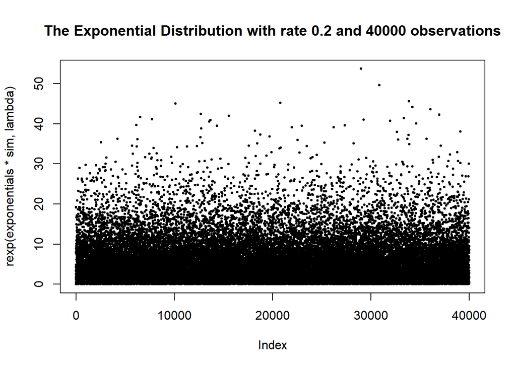

```r
ECHO=TRUE
set.seed(157)
lambda = 0.2
exponentials = 40
sim = 1000

#the exponential distribution
plot(rexp(exponentials*sim, lambda), pch = 20, cex = 0.6, main = "The Exponential Distribution with rate 0.2 and 40000 observations")
```

Run Simulations with variables and plots the distribution

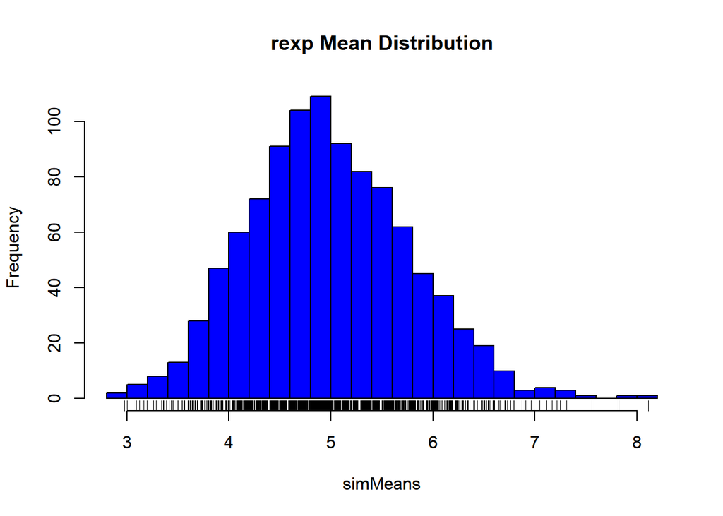

```r
simMeans = NULL
for (i in 1 : 1000) simMeans = c(simMeans, mean(rexp(exponentials, lambda)))
hist(simMeans, col = "blue", main = "rexp Mean Distribution", breaks = 20)
rug(simMeans)
```

## Sample Mean versus Theoretical Mean

#### Sample Mean

Calculating the mean from the simulations with give the sample mean.

```r
mean(simMeans)
```

```
## [1] 4.978361
```

#### Theoretical Mean

The theoretical mean of an exponential distribution is lambda^-1.

```r
lambda^-1
```

```
## [1] 5
```

#### Comparison

There is only a slight difference between the simulations sample mean and the exponential distribution theoretical mean.

```r
abs(mean(simMeans)-lambda^-1)
```

```
## [1] 0.02163885
```

#### Plot Comparing Theoretical Mean vs Sample Mean

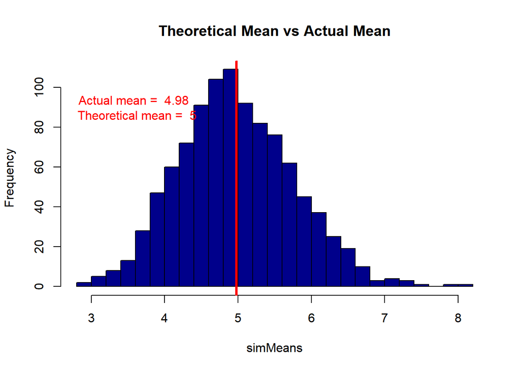

```r
hist(simMeans, col="darkblue", main="Theoretical Mean vs Actual Mean", breaks=20)
abline(v=mean(simMeans), lwd="3", col="red")
text(3.6, 90, paste("Actual mean = ", round(mean(simMeans),2), "\n Theoretical mean = ", round(lambda^-1,2) ), col="red")
```

## Sample Variance versus Theoretical Variance

#### Sample Variance

Calculating the variance from the simulation means with given sample variance.

```r
var(simMeans)
```

```
## [1] 0.619628
```

#### Theoretical Variance

The theoretical variance of an exponential distribution is (1/lambda)^2/exponentials.

```r
(1/lambda)^2/exponentials
```

```
## [1] 0.625
```

## Sample Standard Deviation versus Theoretical Standard Deviation

### Sample Standard Deviation

Calculating the standard deviation for the simulation means.

```r
sd(simMeans)
```

```
## [1] 0.7871646
```

### Theortical Standard Deviation

The theoretical standard deviation of an exponential distribution is sqrt((1/lambda)^2/exponentials).

```r
sqrt((1/lambda)^2/exponentials)
```

```
## [1] 0.7905694
```

#### Comparison

There is only a slight difference between the simulations sample variance and the exponential distribution theoretical variance.

```r
abs(sd(simMeans)-sqrt((1/lambda)^2/exponentials))
```

```
## [1] 0.003404856
```